# a3_task3_aaron_kreisberg

Aaron Kreisberg

11/06/2020

First the urchins.csv file will be read in using read.csv(here(“data”, “urchins.csv”)) from the data folder in the R.project, and names will be cleaned using clean_names()

```r
urchins <- read.csv(here("data", "urchins.csv")) %>%
  clean_names()
```

## Section 1 - Size Comparison of purple and red urchins

# Exploratory data visualization of purple and red urchins

First the distribution of sizes of purple and red urchins will be examined visually. This will be done by using gg_plot, with both a faceted histogram (ggplot() + geom_histogram + facet_wrap(~common_name)) and a boxplot (ggplot() + geom_boxplot())

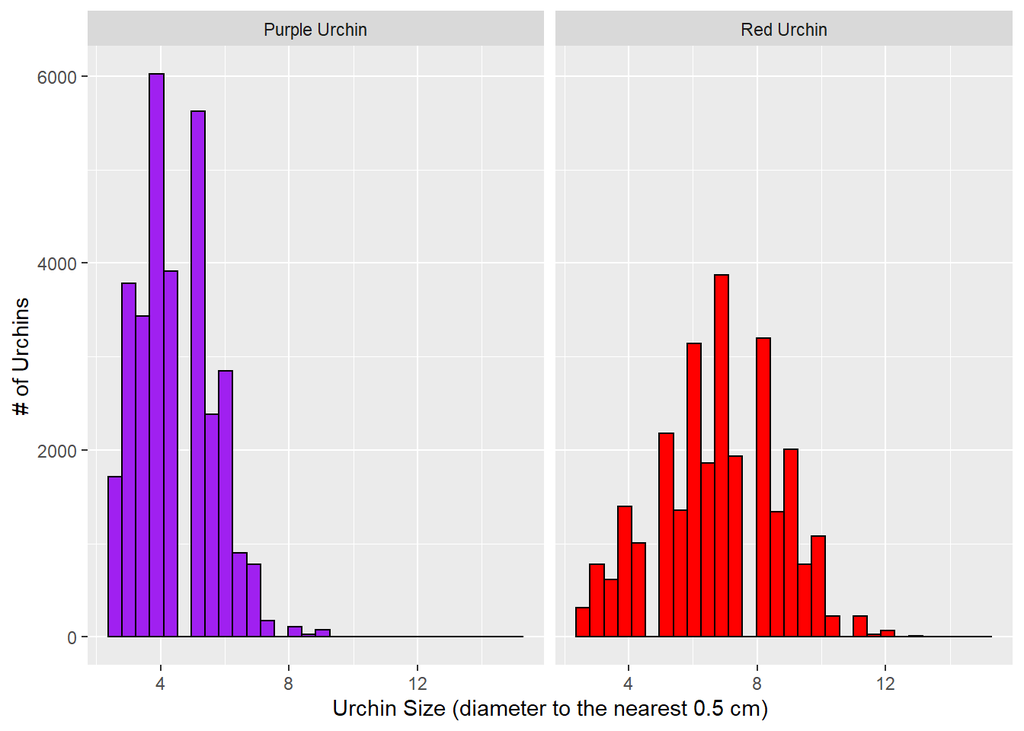

```r
ggplot(data = urchins, aes(x = size, fill = common_name)) +
  geom_histogram(color = "black") +
  facet_wrap(~common_name) +
  scale_fill_manual(values = c("purple", "red")) +
  theme(legend.position = "none") +
  labs(x = "Urchin Size (diameter to the nearest 0.5 cm)", y = "# of Urchins")
```

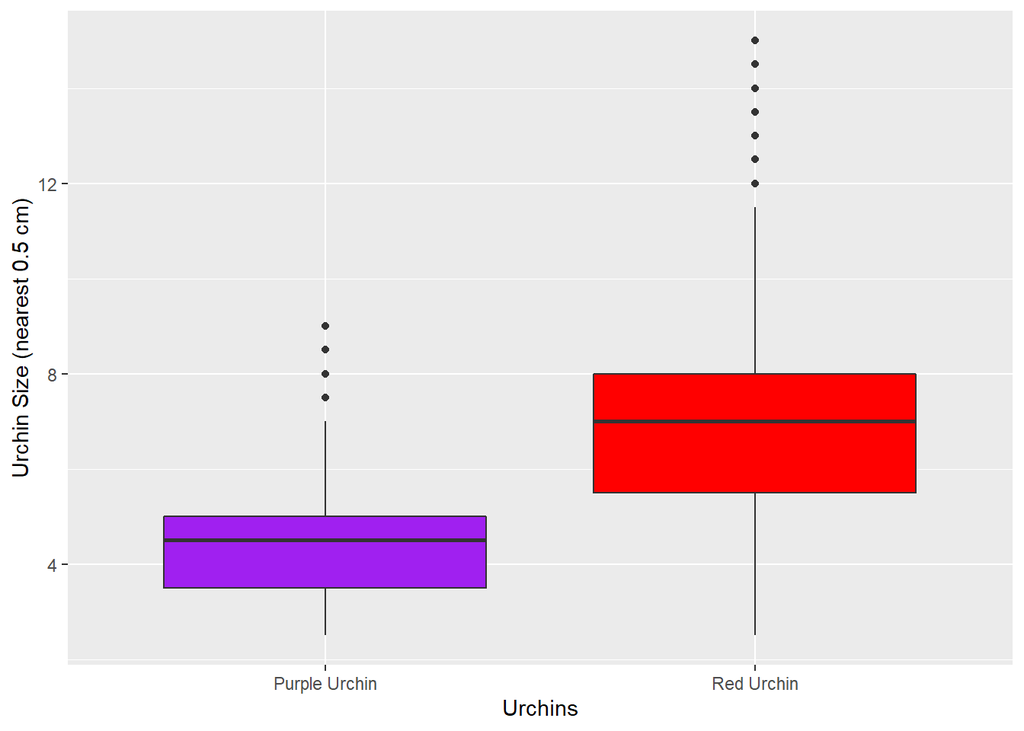

```r
ggplot(data = urchins, aes(x = common_name, y = size, fill = common_name)) +
  geom_boxplot() +
  scale_fill_manual(values = c("purple", "red")) +
  theme(legend.position = "none") +
  labs(x = "Urchins", y ="Urchin Size (nearest 0.5 cm)")
```